# Final Project

STA3241.01 – April 27, 2020

Luiz Gustavo Fagundes Malpele, Cindy Nguyen, Isabel Zimmerman

# Introduction

The aim of this report was to predict early and mid career pay for college graduates from data collected on independent variables such as: tuition costs, school enrollment size, percentage STEM of majors, percentage of minority students, etc. After a robust exploratory data analysis, various regression algorithms were created utilizing the libraries `tidyverse`, `caret`, `DataExplorer`, `fastDummies`, `leaps`, `cowplot`, and `GGally`. All of the R code can be found at the GitHub [here](https://github.com/luizmalpele/stats_learning_project/).

# Dataset

We began by importing processed data from TidyTuesday, which can also be found [here](https://github.com/luizmalpele/stats_learning_project/blob/master/data/data.Rmd).

From this data, we transformed all minority variables into percentages of total enrollment, and took the log of the following variables: early career pay, mid career pay, in state tuition, out of state tuition, room and board, and total enrollment. This was to create more normal distributions in the data and possibly remove heteroscedasticity. With the addition of these two features in the data, some of the models (particularly linear models) may improve in predictive power.

## Data Dictionary

| Field Name | Description | Data Type | Number of Observations |
| --- | --- | --- | --- |
| name | Institution Name | factor | 486 |
| state_code | State Abbreviation | factor | 486 |
| make_world_better_percent | Percent of alumni who think they are making the world a better place | integer | 486 |
| room_and_board | Room and board in USD | integer | 486 |
| ln_room_and_board | Natural Log of Room and board in U$D | double | 486 |
| early_career_pay | Estimated early career pay in USD | int | 486 |
| ln_early_career_pay | Natural log of estimated early career pay in USD | double | 486 |
| mid_career_pay | Estimated mid career pay in USD | int | 486 |
| ln_mid_career_pay | Natural log of estimated mid career pay in USD | double | 486 |
| total_enrollment | Total enrollment of students | double | 486 |
| ln_total_enrollment | Natural Log of Total enrollment of students | double | 486 |
| out_of_state_tuition | Tuition for out-of-state residents in USD | integer | 486 |
| ln_out_of_state_tuition | Natural Log of Tuition for out-of-state residents in USD | double | 486 |
| in_of_state_tuition | Tuition for in-of-state residents in USD | integer | 486 |
| ln_in_of_state_tuition | Natural Log of Tuition for in-of-state residents in USD | double | 486 |
| stem_percent | Percent of student body in STEM | double | 486 |
| private | Type: 0 for Public, 1 for Private | integer | 486 |
| asian_ratio | Percentage of Asian Students | double | 486 |
| black_ratio | Percentage of Black Students | double | 486 |
| minority_ratio | Percentage of all Minorities Combined | double | 486 |
| hispanic_ratio | Percentage of Hispanic Students | double | 486 |
| women_ratio | Percentage of Women Students | double | 486 |
| tuition_ratio | Out-of-State Tuition and In-State Tuition Ratio | double | 486 |

## Exploratory Data Analysis

The first step was to use the `DataExplorer` package to automatically create an EDA. This report can be found [here](https://github.com/luizmalpele/stats_learning_project/blob/master/project/EDA_report.html). Using this process was preferred as it automatically created all the univariate distributions and correlation matricies for the variables. This way, we were able to focus on creating more complex explorations that were fine-tuned to the question we wanted to answer.

```r
#create_report(college_dataset)
```

The first look into the data was to see how the distribution of pay shifted from early to mid career. We could tell that the distribution became wider and right-skewed for mid career pay and was higher on average; the mean early pay was $51,000 whereas the mid career pay average was $92,000.

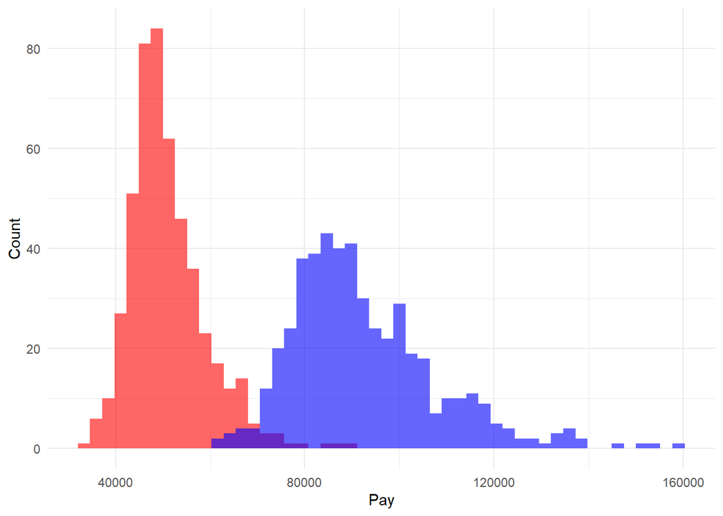

We next wanted to understand more thoroughly the impact of variables we thought would be higly significant in our regression models. The first variable we chose to explore was *stem_percent* as STEM majors tend to have higher paid jobs both right out of college and over time. In Figure A, it is observed that both early and mid career pay has relatively normal distributions. However, when observing schools with higher than 30% STEM majors in Figure B, there is no longer a normal distribution; both early and mid career pay are observed to be proportionally hight, but do note that the sample size is much smaller for this visualization. Finally, we see that the less than 30% STEM majors has a relatively similar distribution as the school totals; that is, this distribution is fairly normal.

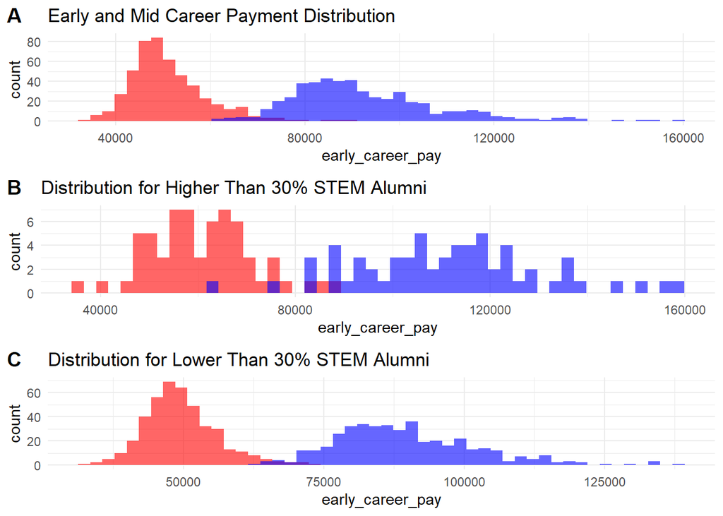

# Modeling

## Preprocessing

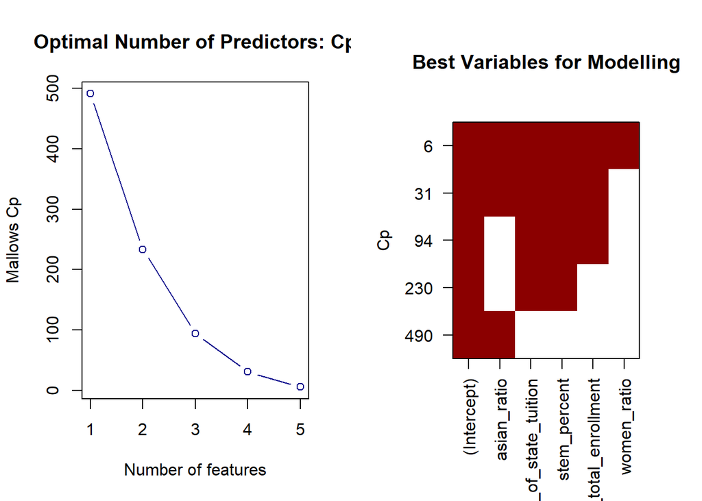

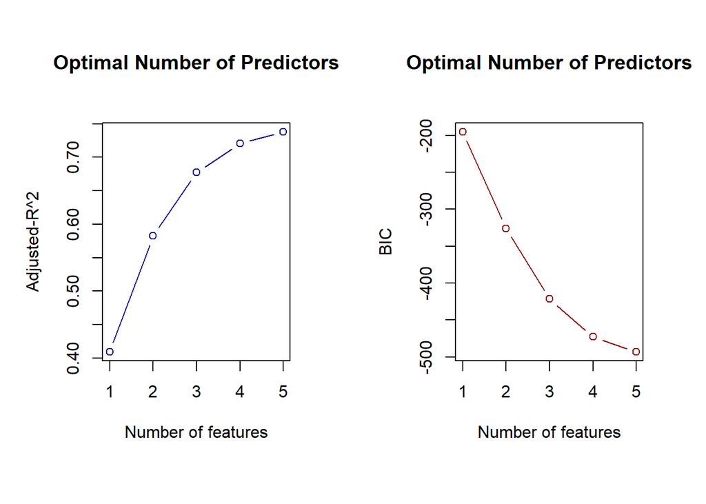

Based on the EDA, BIC, Mallows’ CP, and the $Adjusted-R^2$, the models will be tested on the following predictors: *ln_early_career_pay, asian_ratio, ln_out_of_state_tuition, stem_percent, ln_total_enrollment,* and *women_ratio*.. More than this will result in overfitting.

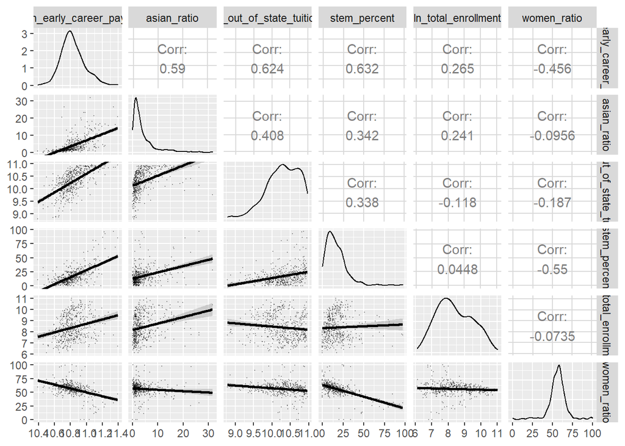

We then formed a correlation matrix between these variables; if variables are highly correlated, they can cause standard errors of models to be unreliable and cause poor models in general. From this, we found that the variables were, at most, about 60% correlated. This was not worrisome in itself, but certainly something to keep in mind when evaluating results.

## Best Model

### Random Forest

```r
oob <- trainControl(method = "oob")
cv_5 <- trainControl(method = "cv", number = 5)
rf_grid <- expand.grid(mtry = 1:10)

set.seed(825)
rf_model <- train(ln_early_career_pay ~ ., data = train_data,
                     method = "rf",
                     trControl = oob,
                     verbose = FALSE,
                     tuneGrid = rf_grid)
# print results
rf_model
```

```
## Random Forest
##
## 391 samples
##   5 predictor
##
## No pre-processing
## Resampling results across tuning parameters:
##
##   mtry  RMSE        Rsquared
##    1    0.07381380  0.7566485
##    2    0.07268202  0.7640539
##    3    0.07326102  0.7602798
##    4    0.07393627  0.7558403
##    5    0.07389827  0.7560913
##    6    0.07456265  0.7516859
##    7    0.07485997  0.7497016
##    8    0.07472893  0.7505771
##    9    0.07486140  0.7496920
##   10    0.07432065  0.7532951
##
## RMSE was used to select the optimal model using the smallest value.
## The final value used for the model was mtry = 2.
```

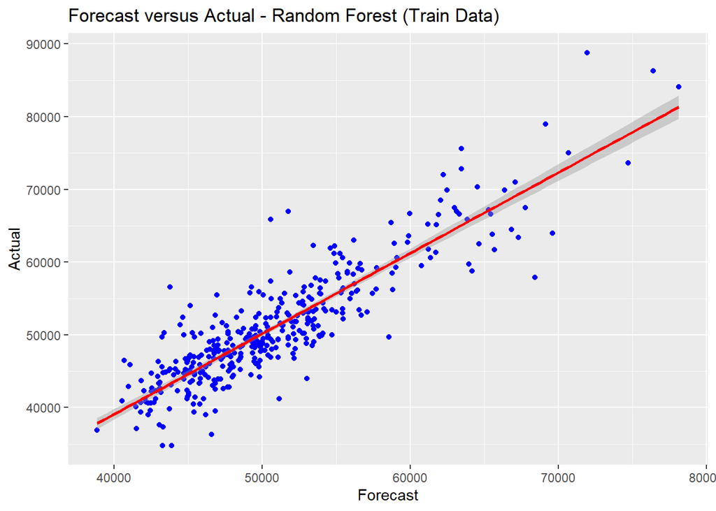

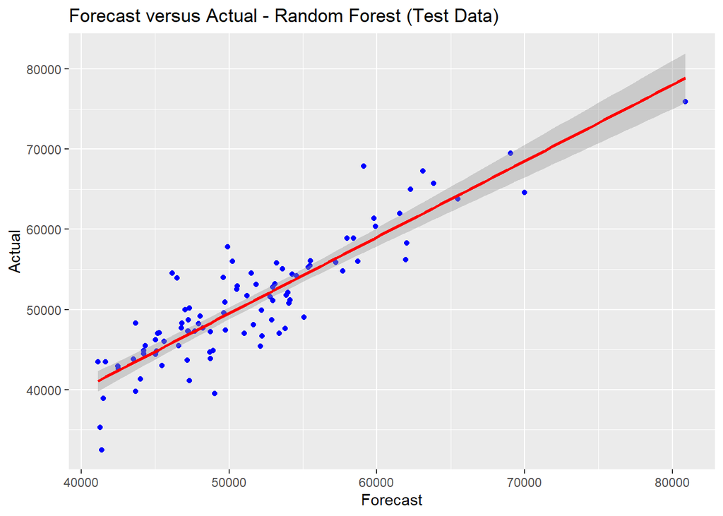

### Model Comparison

[output not shown]